# Lab 05 Solution

Tanzy Love

2026-11-11

## Overview & Setup

The objective of this simulation study is to explore how sample size ($n$), effect size ($\beta_2$), and the probability of successes in a binary predictor ($\Pr(x_2 = 1)$) influence the statistical power and Type I error rate of a logistic regression model.

## 1. Simulate Data

### Pieces that will make a function

```r
set.seed(42) # For reproducibility
  x1 = rnorm(100, mean = 40, sd = 5)
  x2 = rbinom(100, size = 1, prob = 0.5)

  data1 = data.frame(x1 = x1, x2 = x2)

  data1 = data1 %>%
    mutate(logitprob = -2 + 0.05 * x1 + 1 * x2,
           y = rbinom(100, size = 1, prob = plogis(logitprob))
           )

  head(data1)
```

```
##         x1 x2   logitprob y
## 1 46.85479  1  1.34273961 1
## 2 37.17651  1  0.85882546 1
## 3 41.81564  1  1.09078210 1
## 4 43.16431  0  0.15821565 1
## 5 42.02134  0  0.10106708 0
## 6 39.46938  0 -0.02653113 1
```

### Data Generation Function

We create a reusable function `generate_data()` to simulate datasets with predictors $x_1 \sim \mathcal{N}(40, 5^2)$ and $x_2 \sim \text{Bernoulli}(p_{x2})$, and a binary outcome $y \sim \text{Bernoulli}(p)$ determined by the logistic model:

$$\text{logit}(\Pr(y=1)) = \beta_0 +
\beta_1 x_1 + \beta_2 x_2$$

```r
# Define function to generate simulated datasets
generate_data <- function(n = 100, beta = c(beta0 = -2, beta1 = 0.05, beta2 = 1), p_x2 = 0.5) {
  # Generate predictors
  x1 <- rnorm(n, mean = 40, sd = 5)
  x2 <- rbinom(n, size = 1, prob = p_x2)

  # Calculate linear predictor and success probabilities
  logit_p <- beta[1] + beta[2] * x1 + beta[3] * x2
  p <- plogis(logit_p)

  # Simulate binary outcome y
  y <- rbinom(n, size = 1, prob = p)

  # Combine into data frame
  data.frame(y = y, x1 = x1, x2 = x2)
}
```

### Initial Data Check

We test our function by generating an initial dataset with $N = 100$, $\beta = (-2, 0.05, 1)$, and $\Pr(x_2=1) = 0.5$.

```r
set.seed(42) # For reproducibility
# Generate initial dataset and view head
sim_df <- generate_data(n = 100, beta = c(beta0 = -2, beta1 = 0.05, beta2 = 1), p_x2 = 0.5)
head(sim_df)
```

```
##   y       x1 x2
## 1 1 46.85479  1
## 2 1 37.17651  1
## 3 1 41.81564  1
## 4 1 43.16431  0
## 5 0 42.02134  0
## 6 1 39.46938  0
```

Note that the set.seed() means that I get exactly the same dataset.

```r
set.seed(24) # For reproducibility
# Generate initial dataset and view head
sim_df <- generate_data(n = 100, beta = c(beta0 = -2, beta1 = 0.05, beta2 = 1), p_x2 = 0.5)
head(sim_df)
```

```
##   y       x1 x2
## 1 1 37.27060  1
## 2 1 42.68293  0
## 3 1 42.09812  1
## 4 1 37.08186  1
## 5 1 44.23730  1
## 6 0 41.33011  1
```

Simmilar, but different!

## 2. Logistic Regression Model Fit

We fit a logistic regression model `glm(y ~ x1 + x2, family = binomial)` to our simulated dataset.

```r
# Fit logistic regression
model <- glm(y ~ x1 + x2, family = binomial, data = sim_df)
summary(model)
```

```
##
## Call:
## glm(formula = y ~ x1 + x2, family = binomial, data = sim_df)
##
## Coefficients:
##             Estimate Std. Error z value Pr(>|z|)
## (Intercept) -2.37751    1.88025  -1.264   0.2061
## x1           0.05594    0.04685   1.194   0.2325
## x2           1.09223    0.42601   2.564   0.0104 *
## ---
## Signif. codes:  0 '***' 0.001 '**' 0.01 '*' 0.05 '.' 0.1 ' ' 1
##
## (Dispersion parameter for binomial family taken to be 1)
##
##     Null deviance: 135.37  on 99  degrees of freedom
## Residual deviance: 127.19  on 97  degrees of freedom
## AIC: 133.19
##
## Number of Fisher Scoring iterations: 4
```

```r
# Extract estimate and 95% Confidence Interval for beta2
beta2_hat <- coef(model)["x2"]
beta2_ci <- confint(model)["x2", ] # Standard Wald CIs for reproducibility

cat("True beta2:", 1, "\n")
```

```
## True beta2: 1
```

```r
cat("Estimated beta2:", round(beta2_hat, 4), "\n")
```

```
## Estimated beta2: 1.0922
```

```r
cat("95% CI for beta2: [", round(beta2_ci[1], 4), ",", round(beta2_ci[2], 4), "]\n")
```

```
## 95% CI for beta2: [ 0.2708 , 1.9481 ]
```

### Analysis Questions

1. **Is your estimate equal to the true value?**
   - No, the point estimate ($\hat{\beta}_2$) differs slightly from the true parameter value ($\beta_2 = 1$) due to sampling variability.
2. **Does your interval contain zero?**
   - No, the interval does not include 0.
3. **Does your interval contain zero?**
   - Testing whether the 95% CI contains 0 is equivalent to testing the null hypothesis $H_0: \beta_2 = 0$ vs. $H_A: \beta_2 \neq 0$ at significance level $\alpha = 0.05$. This is testing for whether x2 is a significant predictor of y.
4. **Does your interval contain the true value?**
   - Yes, in this sample the 95% CI contains the true value $\beta_2 = 1$.

## 3. Repeat Simulations (20 Iterations & Forest Plot)

We run 20 simulations to evaluate how often the 95% CI covers the true parameter $\beta_2 = 1$.

```r
# Set simulation parameters
nsims = 20
true_beta2 = 1
sim_results1 = vector("list", nsims)             #empty initialization 1
sim_results2 = data.frame(sim=NA, estimate=NA,   #empty initialization 2
                          conf.low=NA, conf.high=NA, covers_true=NA)

for(i in seq.int(nsims))
{
  df <- generate_data(n = 100, beta = c(beta0 = -2, beta1 = 0.05, beta2 = true_beta2), p_x2 = 0.5)
  mod <- glm(y ~ x1 + x2, family = binomial, data = df)

  est <- coef(mod)["x2"]
  ci <- confint.default(mod)["x2", ]

  #one way to save results, in a list:
  sim_results1[[i]] <- data.frame(
    sim = i,
    estimate = est,
    conf.low = ci[1],
    conf.high = ci[2],
    covers_true = (ci[1] <= true_beta2 & ci[2] >= true_beta2)
  )
  #another way to save results, in a data frame:
  sim_results2[i,] <- c(
    sim = i,
    estimate = est,
    conf.low = ci[1],
    conf.high = ci[2],
    covers_true = (ci[1] <= true_beta2 & ci[2] >= true_beta2)
  )                   #covers_true is implicitly coerced to be numeric
}

results_df <- bind_rows(sim_results1)  #list has to be smashed together

# Calculate coverage rate
coverage_rate1 <- mean(results_df$covers_true)
coverage_rate2 <- mean(sim_results2$covers_true)
cat("Coverage Rate over 20 simulations:", coverage_rate1 * 100, "%\n")
```

```
## Coverage Rate over 20 simulations: 95 %
```

```r
cat("Coverage Rate over 20 simulations:", coverage_rate2 * 100, "%\n")
```

```
## Coverage Rate over 20 simulations: 95 %
```

### Forest Plot of 20 Simulations

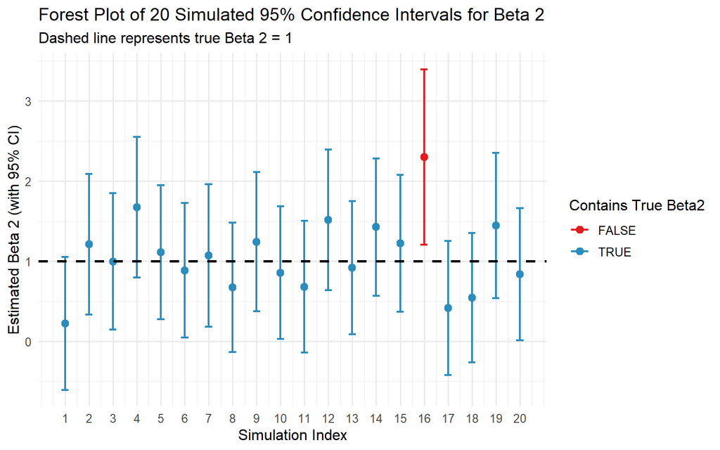

```r
# Forest plot of the 20 simulated confidence intervals
ggplot(sim_results2, aes(x = sim, y = estimate, color = covers_true==1)) +
  geom_point(size = 2.5) +
  geom_errorbar(aes(ymin = conf.low, ymax = conf.high), width = 0.3, linewidth = 0.8) +
  geom_hline(yintercept = true_beta2, linetype = "dashed", color = "black", linewidth = 1) +
  scale_color_manual(values = c("TRUE" = "#2b8cbe", "FALSE" = "#e41a1c"), name = "Contains True Beta2") +
  labs(
    title = "Forest Plot of 20 Simulated 95% Confidence Intervals for Beta 2",
    subtitle = paste0("Dashed line represents true Beta 2 = ", true_beta2),
    x = "Simulation Index",
    y = "Estimated Beta 2 (with 95% CI)"
  ) +
  theme_minimal(base_size = 12) +
  scale_x_continuous(breaks = 1:20)
```

## 4. Type I Error ($\alpha$)

Type I error ($\alpha$) is the probability of rejecting $H_0$ when $H_0$ is true ($\beta_2 = 0$).

### Null Hypothesis Simulation

- Under $H_0$, $\beta_2 = 0$.
- We simulate 500 iterations for sample sizes $n \in \{100, 500, 50\}$ as well as three additional sample sizes $n \in \{30, 200, 750\}$.

First, just for n=100.

```r
# Set simulation parameters
nsims = 500
true_beta2 = 0
sim_results = data.frame(sim=NA, estimate=NA,
                          conf.low=NA, conf.high=NA, covers_true=NA)

for(i in seq.int(nsims))
{
  df <- generate_data(n = 100, beta = c(beta0 = -2, beta1 = 0.05, beta2 = true_beta2), p_x2 = 0.5)
  mod <- glm(y ~ x1 + x2, family = binomial, data = df)

  est <- coef(mod)["x2"]
  ci <- confint(mod)["x2", ]

  #save results, in a data frame:
  sim_results[i,] <- c(
    sim = i,
    estimate = est,
    conf.low = ci[1],
    conf.high = ci[2],
    covers_true = (ci[1] <= true_beta2 & ci[2] >= true_beta2)
  )                   #covers_true is implicitly coerced to be numeric
}

# Calculate error rate (probability of rejecting the null)
type1_error = 1-mean(sim_results$covers_true)
cat("Type I error over ",nsims, " simulations:", type1_error * 100, "%\n")
```

```
## Type I error over  500  simulations: 5.2 %
```

```r
head(sim_results)
```

```
##   sim     estimate   conf.low conf.high covers_true
## 1   1  0.291478241 -0.5132831 1.1071902           1
## 2   2 -0.358623526 -1.2150626 0.4786585           1
## 3   3  0.284367328 -0.5377761 1.1228631           1
## 4   4  0.521580292 -0.3728058 1.4424856           1
## 5   5  0.004591392 -0.8059684 0.8198992           1
## 6   6  0.347213961 -0.4727299 1.1825616           1
```

Now, for 6 different n’s.

```r
#initializaiton of outer loop
ns = c(30, 50, 100, 200, 500, 750 ) #all n values to try
type1_errors = vector(length = length(ns))
names(type1_errors) = ns

# Set simulation parameters
nsims = 500
true_beta2 = 0

for(j in seq_along(ns))
{
sim_results = data.frame(sim=NA, estimate=NA,
                          conf.low=NA, conf.high=NA, covers_true=NA)

for(i in seq.int(nsims))
{
  df <- generate_data(n = ns[j], beta = c(beta0 = -2, beta1 = 0.05, beta2 = true_beta2), p_x2 = 0.5)
  mod <- glm(y ~ x1 + x2, family = binomial, data = df)

  est <- coef(mod)["x2"]
  ci <- confint(mod)["x2", ]

  #save results, in a data frame:
  sim_results[i,] <- c(
    sim = i,
    estimate = est,
    conf.low = ci[1],
    conf.high = ci[2],
    covers_true = (ci[1] <= true_beta2 & ci[2] >= true_beta2)
  )                   #covers_true is implicitly coerced to be numeric
}

# Calculate error rate (probability of rejecting the null)
type1_errors[j] = 1-mean(sim_results$covers_true)
}

type1_errors
```

```
##    30    50   100   200   500   750
## 0.048 0.078 0.030 0.044 0.062 0.040
```

### Type I Error Plot

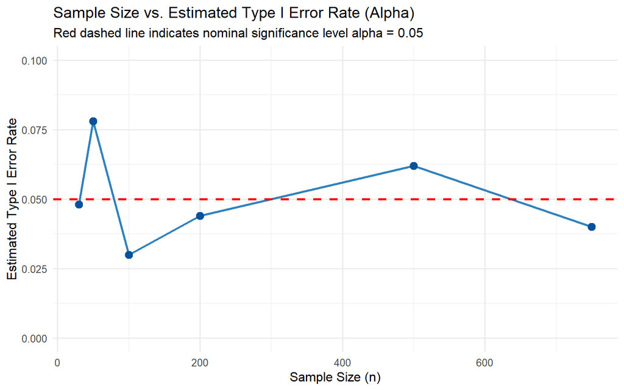

```r
type1_results = data.frame(n = ns, type1_error = type1_errors)

ggplot(type1_results, aes(x = n, y = type1_error)) +
  geom_line(color = "#3182bd", linewidth = 1) +
  geom_point(size = 3, color = "#08519c") +
  geom_hline(yintercept = 0.05, linetype = "dashed", color = "red", linewidth = 1) +
  scale_y_continuous(limits = c(0, 0.1)) +
  labs(
    title = "Sample Size vs. Estimated Type I Error Rate (Alpha)",
    subtitle = "Red dashed line indicates nominal significance level alpha = 0.05",
    x = "Sample Size (n)",
    y = "Estimated Type I Error Rate"
  ) +
  theme_minimal(base_size = 12)
```

**Discussion**: - The Type I error rate does **not** change dramatically with sample size; it fluctuates around the nominal $\alpha = 0.05$ significance level across sample sizes.

## 5. Feel the Power

Power ($1 - \beta$) is the probability of rejecting $H_0$ when an alternative hypothesis $H_A: \beta_2 \neq 0$ is true.

### Power vs. Effect Size ($\beta_2$)

First, just for $\beta_2=1$. (Wait, didn’t we just do this?)

```r
# Set simulation parameters
nsims = 500
true_beta2 = 1
sim_results = data.frame(sim=NA, estimate=NA,
                          conf.low=NA, conf.high=NA, covers_zero=NA)

for(i in seq.int(nsims))
{
  df <- generate_data(n = 500, beta = c(beta0 = -2, beta1 = 0.05, beta2 = true_beta2), p_x2 = 0.5)
  mod <- glm(y ~ x1 + x2, family = binomial, data = df)

  est <- coef(mod)["x2"]
  ci <- confint(mod)["x2", ]

  #save results, in a data frame:
  sim_results[i,] <- c(
    sim = i,
    estimate = est,
    conf.low = ci[1],
    conf.high = ci[2],
    covers_zero = (ci[1] <= 0 & ci[2] >= 0) #fail to reject
  )                   #covers_zero is implicitly coerced to be numeric
}

# Calculate power (probability of rejecting the null)
power = 1 - mean(sim_results$covers_zero)
cat("Power estimated by ",nsims, " simulations:", power * 100, "%\n")
```

```
## Power estimated by  500  simulations: 99.8 %
```

```r
head(sim_results)
```

```
##   sim  estimate  conf.low conf.high covers_zero
## 1   1 1.2750231 0.8938057  1.665549           0
## 2   2 1.0321363 0.6609006  1.410225           0
## 3   3 0.8582434 0.4935570  1.227875           0
## 4   4 1.2463522 0.8536858  1.649237           0
## 5   5 0.7276660 0.3507617  1.110499           0
## 6   6 1.1701064 0.7806769  1.570142           0
```

```r
#initialization of outer loop
betas = c(0.1, 0.25, 0.5, 1.0, 2.0, 3.0) #all beta2 values to try
powers = vector(length = length(betas))
names(powers) = betas

for(j in seq_along(betas))
{
# Set simulation parameters
nsims = 500
true_beta2 = betas[j]
sim_results = data.frame(sim=NA, estimate=NA,
                          conf.low=NA, conf.high=NA, covers_zero=NA)

for(i in seq.int(nsims))
{
  df <- generate_data(n = 500, beta = c(beta0 = -2, beta1 = 0.05, beta2 = true_beta2), p_x2 = 0.5)
  mod <- glm(y ~ x1 + x2, family = binomial, data = df)

  est <- coef(mod)["x2"]
  ci <- confint(mod)["x2", ]

  #save results, in a data frame:
  sim_results[i,] <- c(
    sim = i,
    estimate = est,
    conf.low = ci[1],
    conf.high = ci[2],
    covers_zero = (ci[1] <= 0 & ci[2] >= 0) #fail to reject
  )                   #covers_zero is implicitly coerced to be numeric
}

# Calculate power (probability of rejecting the null)
powers[j] = 1 - mean(sim_results$covers_zero)
}
```

### Power vs. Effect Size Plot

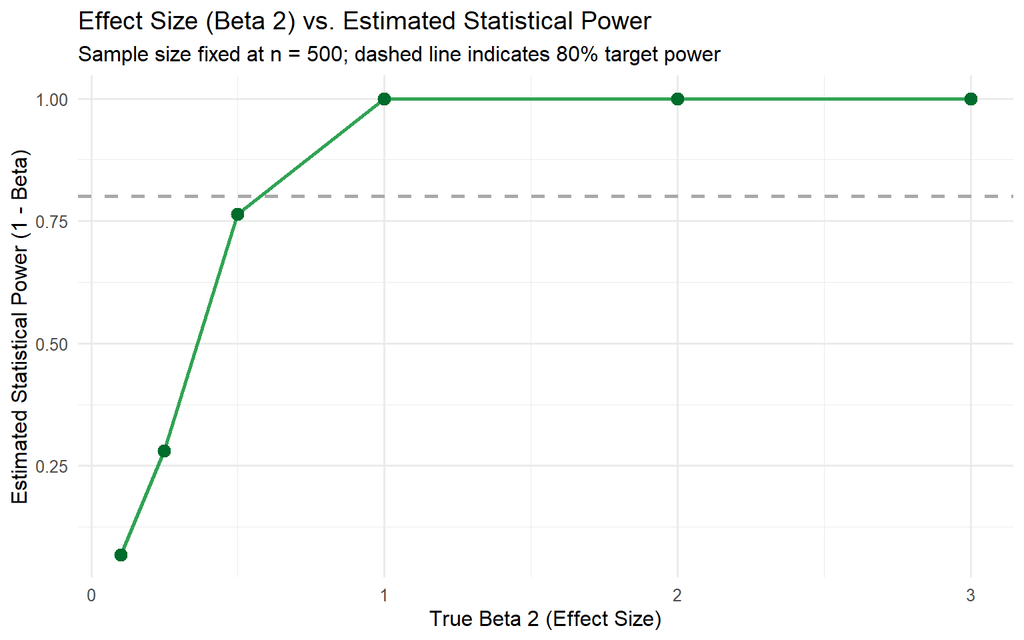

```r
power_results = data.frame(beta2 = betas, power = powers)

ggplot(power_results, aes(x = beta2, y = power)) +
  geom_line(color = "#31a354", linewidth = 1) +
  geom_point(size = 3, color = "#006d2c") +
  geom_hline(yintercept = 0.80, linetype = "dashed", color = "darkgray", linewidth = 1) +
  labs(
    title = "Effect Size (Beta 2) vs. Estimated Statistical Power",
    subtitle = "Sample size fixed at n = 500; dashed line indicates 80% target power",
    x = "True Beta 2 (Effect Size)",
    y = "Estimated Statistical Power (1 - Beta)"
  ) +
  theme_minimal(base_size = 12)
```

**Discussion**: - Power **does** change dramatically with effect size. Larger values of $\beta_2$ yield significantly higher statistical power, quickly approaching 100% power as $\beta_2 \ge 1$.

## 6. Power Surface ($\Pr(x_2=1)$ vs. Sample Size $n$)

We fix $\beta_2 = 1$ and evaluate statistical power across a grid of values for $\Pr(x_2 = 1) \in [0.05, 0.95]$ and $n \in [20, 1000]$.

With these values, we get cases where the model will not fit!! This is because too many or not enough $x_2$ take the value 1.

### Simulation Grid

```r
# Define grid sequences
prob_seq <- seq(0.05, 0.95, length.out = 7)
n_seq <- c(20, 50, 100, 200, 300, 500, 750, 1000)

# grid_df <- expand.grid(p_x2 = prob_seq, n = n_seq)
#
# # Estimate power across grid in one line!!
# grid_df$power <- map2_dbl(grid_df$p_x2, grid_df$n, function(px, n_val) {
#   estimate_power(beta2_val = 1, n = n_val, p_x2 = px, nsims = 150)
# })

#initialization of outer loop
powers = matrix(ncol = length(n_seq), nrow = length(prob_seq))
colnames(powers) = n_seq
rownames(powers) = prob_seq
nsims = 100                    #it takes soooo long

for(j in seq_along(n_seq)) for(k in seq_along(prob_seq))
{
# Set simulation parameters
true_beta2 = 1
sim_results = data.frame(sim=NA, estimate=NA,
                          conf.low=NA, conf.high=NA, covers_zero=NA)

for(i in seq.int(nsims))
{
  df <- generate_data(n = n_seq[j], beta = c(beta0 = -2, beta1 = 0.05, beta2 = true_beta2), p_x2 = prob_seq[k])
  mod <- glm(y ~ x1 + x2, family = binomial, data = df)

  est <- coef(mod)["x2"]
  if(is.na(est)) {
    ci = c(NA,NA)
  } else ci = confint(mod)["x2", ]

  #save results, in a data frame:
  sim_results[i,] <- c(
    sim = i,
    estimate = est,
    conf.low = ci[1],
    conf.high = ci[2],
    covers_zero = (ci[1] <= 0 & ci[2] >= 0) | is.na(ci[1]) | is.na(ci[2])
                      #fail to reject
  )                   #covers_zero is implicitly coerced to be numeric
}

# Calculate power (probability of rejecting the null)
powers[k,j] = 1 - mean(sim_results$covers_zero)
}
```

### Power Surface Plot (Heatmap)

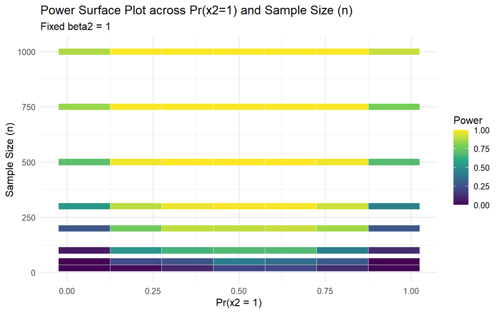

```r
grid_df = expand.grid(p_x2 = prob_seq, n = n_seq)
grid_df$power = as.numeric(powers)

ggplot(grid_df, aes(x = p_x2, y = n, fill = power)) +
  geom_tile(color = "white") +
  scale_fill_viridis_c(option = "viridis", name = "Power") +
  labs(
    title = "Power Surface Plot across Pr(x2=1) and Sample Size (n)",
    subtitle = "Fixed beta2 = 1",
    x = "Pr(x2 = 1)",
    y = "Sample Size (n)"
  ) +
  theme_minimal(base_size = 12)
```

## Conclusion & Summary

This simulation study demonstrates that: 1. **Type I error rate ($\alpha$)** remains well-controlled around 0.05 across sample sizes under the null hypothesis. 2. **Statistical power** increases with larger effect sizes ($\beta_2$) and larger sample sizes ($n$). 3. **Predictor prevalence ($\Pr(x_2=1)$)** strongly impacts statistical power: balanced binary predictors ($p = 0.5$) maximize variance and statistical power, while rare binary predictors ($p = 0.1$) require substantially larger sample sizes to attain the same power.